# proj_1

## Project for P0

### Q1:

Dependent variable: response time / performance of participants Independent variable: whether the participants were tested with congruent or incongruent task

### Q2a:

Null hypothesis: $H_0$: $\mu_1 = \mu_2$, there's no difference with performance between participants who joined congruent or incongruent task

Alternative hypothesis: $H_A$: $\mu_1 < \mu_2$, there's difference with performance between participants who joined congruent or incongruent task

$\mu_1$ is mean performance of people in congruent task $\mu_2$ is mean performance of people in incongruent task In such sample, the mean performance of people in incongruent task is bigger than in congruent task (22.0 > 14.05), so I set up directional hypothesis test above.

```python
import pandas as pd
import numpy as np
import csv
```

```python
data_stroop = pd.read_csv('stroopdata.csv')
data_stroop.head()
```

|  | Congruent | Incongruent |
| --- | --- | --- |
| 0 | 12.079 | 19.278 |
| 1 | 16.791 | 18.741 |
| 2 | 9.564 | 21.214 |
| 3 | 8.630 | 15.687 |
| 4 | 14.669 | 22.803 |

### Q2b:

Perform test to exam hypothesis. Because the population variance is unknown, and because each individual take both congruent and inconguent tasks, I will use dependent t-test.

```python
group1 = data_stroop['Congruent'].tolist()
group2 = data_stroop['Incongruent'].tolist()
```

### Q3: Report descriptive statistics

```python
np.mean(group1), np.mean(group2)
```

```
(14.051124999999999, 22.015916666666666)
```

```python
np.var(group1, ddof=1), np.var(group2, ddof=1)
```

```
(12.669029070652176, 23.011757036231884)
```

### Q4: Plot data

```python
import matplotlib.pyplot as plt
```

```python
# re-stack data
x = ['congruent', 'incongruent']
labels = np.repeat(x, [24, 24], axis=0)
df = pd.DataFrame({'label':labels, 'performance':group1+group2})
```

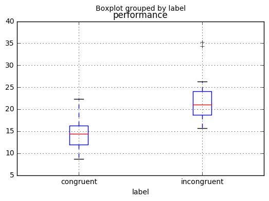

```python
df.boxplot(column='performance', by='label')
plt.show()
```

From the plot, we can see the 2 groups have different center, it seems incongruent task take participants longer time than congruent task.

### Q5

```python
from scipy import stats
```

```python
stats.ttest_rel(group1, group2)   # Dependent t test, because each individual takes both congruent and incongruent tasks
```

```
Ttest_relResult(statistic=-8.020706944109957, pvalue=4.1030005857111781e-08)
```

By 0.95 significant level, and p-value < $\alpha$ = 0.05 (one-tail), we reject null hypothesis and conclude that participants in congruent performance much faster than participants in incongruent task.